# Компьютерная домашняя работа 1

Копчев Владислав, ПСА-1, 198-2

13.04.2021

Загрузка пакетов:

```r
#install.packages("ggm")
library(ggm)
library(ggpubr)
library(ppcor)
library(factoextra)
```

1. Данные позволяют сравнить 80 государств между собой по следующим показателям: state: название государства area: площадь территории государства population: население государства GDP: ВВП по ППС на дущу населения в долларах publications_count: общее количество научно-исследовательских статей, опубликованных в рецензируемых научных изданиях, включённых в систему индекса научного цитирования primary_ed_idx: индекс качества начального образования по версии ВЭФ education_spending: общий объём государственных и частных расходов на образование, выраженный в процентах от ВВП avg_salary: срелняя заработная плата в долларах Все показатели берутся за фиксированный 2018 год, и поэтому данные являются пространственными.

Импорт данных и визуализация данных в виде таблицы:

```r
data <- read.csv("data.csv", head = TRUE, sep = ";")
data
```

| state | area | population | GDP | publications_count | primary_ed_idx | education_spending | avg_salary |
| --- | --- | --- | --- | --- | --- | --- | --- |
| Argentina | 2780400 | 44694198 | 23283 | 8811 | 3.3 | 5.5 | 845.53 |
| Australia | 7686850 | 23470145 | 51036 | 53610 | 5.4 | 5.3 | 3306.13 |
| Austria | 83858 | 8793370 | 56871 | 12362 | 4.8 | 5.5 | 1982.06 |
| Bangladesh | 144000 | 159453001 | 3998 | 3135 | 3.1 | 2.0 | 331.59 |
| Belgium | 30528 | 11570762 | 52250 | 15688 | 5.7 | 6.5 | 2048.73 |
| Botswana | 581730 | 2249104 | 18050 | 281 | 3.8 | 9.6 | 680.00 |
| Brasilia | 8515767 | 208846892 | 14941 | 60148 | 2.6 | 6.2 | 586.63 |
| Brunei | 5770 | 450565 | 61814 | 294 | 5.0 | 4.4 | 1100.15 |
| Canada | 9984670 | 35881659 | 50078 | 59968 | 5.6 | 5.3 | 2253.74 |
| Chile | 756950 | 17925262 | 24765 | 7122 | 3.2 | 5.4 | 872.62 |

[output cut: 70 more lines]

Проведу корреляционный анализ.

Диаграмма рассеяния для количества публикаций и ВВП:

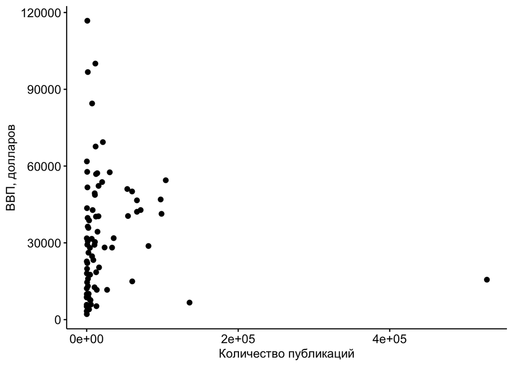

```r
ggscatter(data, x = "publications_count", y = "GDP",
          xlab = "Количество публикаций", ylab = "ВВП, долларов")
```

Имеется 1 нетипичное наблюдение:

```r
data_new <- data[-which(data$publications_count %in% sort(data$publications_count)[(nrow(data)+0):nrow(data)]),]
```

После удаления

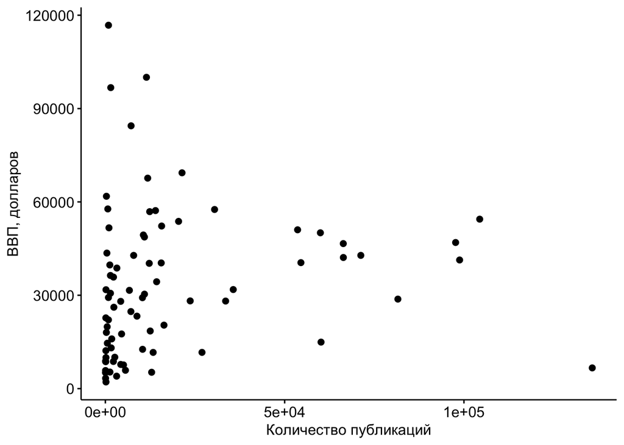

```r
ggscatter(data_new, x = "publications_count", y = "GDP",
          xlab = "Количество публикаций", ylab = "ВВП, долларов")
```

Построю диаграмму рассеяния для средней зарплаты и расходов на образование:

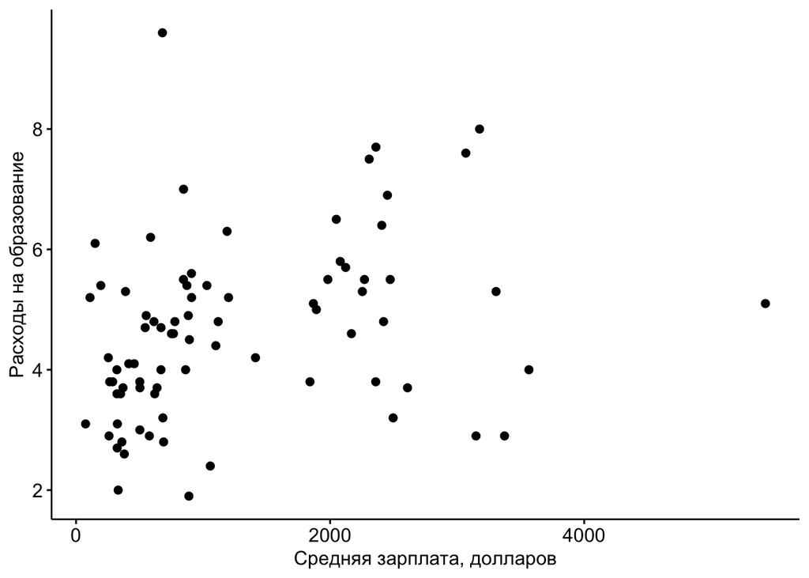

```r
ggscatter(data, x = "avg_salary", y = "education_spending",
          xlab = "Средняя зарплата, долларов", ylab = "Расходы на образование")
```

```r
data_new <- data_new[-which(data$avg_salary %in% sort(data$avg_salary)[(nrow(data)+0):nrow(data)]),]
```

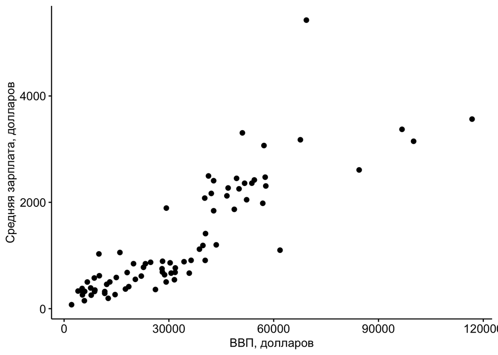

```r
ggscatter(data_new, x = "GDP", y = "avg_salary",
          xlab = "ВВП, долларов", ylab = "Средняя зарплата, долларов")
```

Видно, что корреляция близка к единице: точки выстроены будто бы вдоль прямой.

Посчитаю коэффициент корреляции между ВВП и средней зарплатой до удаления и после:

```r
print("after del:")
```

```
## [1] "after del:"
```

```r
cor(data_new["GDP"], data_new["avg_salary"], method = "pearson")
```

```
##     avg_salary
## GDP  0.8525984
```

```r
print("before del:")
```

```
## [1] "before del:"
```

```r
cor(data["GDP"], data["avg_salary"], method = "pearson")
```

```
##     avg_salary
## GDP   0.854747
```

Построю теперь корреляционную матрицу до и после удаления выбросов:

```r
print("before del:")
```

```
## [1] "before del:"
```

```r
cor(data[2:8])
```

```
##                           area  population         GDP publications_count
## area                1.00000000  0.40317525 -0.08097167         0.49819385
## population          0.40317525  1.00000000 -0.22429629         0.80768423
## GDP                -0.08097167 -0.22429629  1.00000000        -0.02118092
## publications_count  0.49819385  0.80768423 -0.02118092         1.00000000
## primary_ed_idx     -0.01706675 -0.03363362  0.66433435         0.14091066
## education_spending -0.08230712 -0.26528222  0.22622687        -0.19161460
## avg_salary         -0.03751289 -0.14726918  0.85474699         0.07186405
##                    primary_ed_idx education_spending  avg_salary
## area                  -0.01706675        -0.08230712 -0.03751289
## population            -0.03363362        -0.26528222 -0.14726918
## GDP                    0.66433435         0.22622687  0.85474699
## publications_count     0.14091066        -0.19161460  0.07186405
## primary_ed_idx         1.00000000         0.29008907  0.67583936
## education_spending     0.29008907         1.00000000  0.31079606
## avg_salary             0.67583936         0.31079606  1.00000000
```

```r
print("after del:")
```

```
## [1] "after del:"
```

```r
cor(data_new[2:8])
```

```
##                            area  population         GDP publications_count
## area                1.000000000  0.22779078 -0.06138851        0.425167265
## population          0.227790783  1.00000000 -0.24195453        0.565968435
## GDP                -0.061388512 -0.24195453  1.00000000        0.108265362
## publications_count  0.425167265  0.56596843  0.10826536        1.000000000
## primary_ed_idx     -0.035649325 -0.09026968  0.67450533        0.228357341
## education_spending -0.005664002 -0.16663292  0.22292477       -0.002407837
## avg_salary         -0.029803926 -0.17314040  0.85259836        0.233674566
##                    primary_ed_idx education_spending  avg_salary
## area                  -0.03564933       -0.005664002 -0.02980393
## population            -0.09026968       -0.166632919 -0.17314040
## GDP                    0.67450533        0.222924769  0.85259836
## publications_count     0.22835734       -0.002407837  0.23367457
## primary_ed_idx         1.00000000        0.307721770  0.68125003
## education_spending     0.30772177        1.000000000  0.31759623
## avg_salary             0.68125003        0.317596226  1.00000000
```

Мы видим, что высока связь между переменными publications_count и population, GDP и primary_ed_idx, GDP и avg_salary, primary_ed_idx и avg_salary. Таким образом, есть прямая корреляция между количеством публикаций и населением, а также между ВВП и уровнем начального образования и средней зарплатой. Это можно объяснить следующим образом: чем больше население, тем больше людей идут в науку, тем больше они пишут статей. При этом чем выше ВВП, тем богаче страна, и тем больше денег можно выделить на начальное образование, и тем больше будут зарплаты. Притом чем лучше начальное образование, тем умнее люди, и тем больше они зарабатывают. По значениям коэффиицента корреляции у GDP и primary_ed_idx и GDP и avg_salary мы видим, что в данных есть мультиколлинеарность.

Замечу, что в силу того, что у указанных выше трех пар переменных высокий коэффициент корреляции, а state не является непрерывной переменной. Тогда оставлю переменные publications_count, primary_ed_idx, area, education_spending, чтобы исследовать связь различных показателей сферы науки и образовани (публикации, траты на образование, уровень развития начального образования) с площадью страны так, чтобы выбранные перемнные не слишком сильно коррелировали между собой. Проверю, что коэффициенты коррелчции действительно невысокие.

```r
data_cont = data_new[,c("publications_count", "primary_ed_idx", "area", "education_spending")]
data_cont
```

|  | publications_count | primary_ed_idx | area | education_spending |
| --- | --- | --- | --- | --- |
| 1 | 8811 | 3.3 | 2780400 | 5.5 |
| 2 | 53610 | 5.4 | 7686850 | 5.3 |
| 3 | 12362 | 4.8 | 83858 | 5.5 |
| 4 | 3135 | 3.1 | 144000 | 2.0 |
| 5 | 15688 | 5.7 | 30528 | 6.5 |
| 6 | 281 | 3.8 | 581730 | 9.6 |
| 7 | 60148 | 2.6 | 8515767 | 6.2 |
| 8 | 294 | 5.0 | 5770 | 4.4 |
| 9 | 59968 | 5.6 | 9984670 | 5.3 |
| 10 | 7122 | 3.2 | 756950 | 5.4 |

[output cut: 68 more lines]

```r
cor(data_cont)
```

```
##                    publications_count primary_ed_idx         area
## publications_count        1.000000000     0.22835734  0.425167265
## primary_ed_idx            0.228357341     1.00000000 -0.035649325
## area                      0.425167265    -0.03564933  1.000000000
## education_spending       -0.002407837     0.30772177 -0.005664002
##                    education_spending
## publications_count       -0.002407837
## primary_ed_idx            0.307721770
## area                     -0.005664002
## education_spending        1.000000000
```

Действительно, данные отобраны в соответствии с помтавленными целями.

Стандартизую и нормализую данные:

```r
cluster_data <- scale(data_cont, center=TRUE, scale = TRUE)
cluster_data
```

```
##    publications_count primary_ed_idx        area education_spending
## 1         -0.34074444    -0.98105400  0.70657267         0.58178807
## 2          1.21418792     1.05565887  2.63180408         0.44343603
## 3         -0.21749248     0.47374091 -0.35151767         0.58178807
## 4         -0.53775322    -1.17502665 -0.32791868        -1.83937265
## 5         -0.10205005     1.34661785 -0.37244371         1.27354828
## 6         -0.63681295    -0.49612237 -0.15615874         3.41800492
## 7          1.44111593    -1.65995829  2.95706105         1.06602021
## 8         -0.63636173     0.66771356 -0.38215845        -0.17914816
## 9          1.43486830     1.24963152  3.53344075         0.44343603
## 10        -0.39936809    -1.07804033 -0.08740454         0.51261205
## 12        -0.62896870     0.37675458 -0.36437151         1.61942838
## 13        -0.49811544    -0.30214971 -0.36223614        -0.04079611
## 14        -0.60335339    -0.10817706 -0.38079294         1.13519624
## 15        -0.10590276     0.57072723 -0.35347647         0.65096409
```

[output cut: 70 more lines]

3. Приступлю к иерархической кластеризации. Для начала выберу евклидову метрику, поскольку логично, что если показатель, связанный с наукой и образованием, у двух стран такой, что их разность меньше единицы, то, скорее всего, разница в этом показателе почти незначительна, и возведение получившейся разницы в квдрат сделает ее еще меньше единицы и сблизит страны друг с другом по этому показатлю еще сильнее. При этом, если он разный, то разница, скорее всего, сильная, и ее надо усилить, возведя разницу, большуюю единицы, в квадрат. Таким образом, выберупринцип Варда с евклидовой метрикой:

```r
hclust <- hcut(cluster_data, k = 2, hc_metric = 'euclidian', hc_method = 'ward.D2')
```

Изображу результаты кластеризации на дендограмме и выберу по ней оптимальное их число:

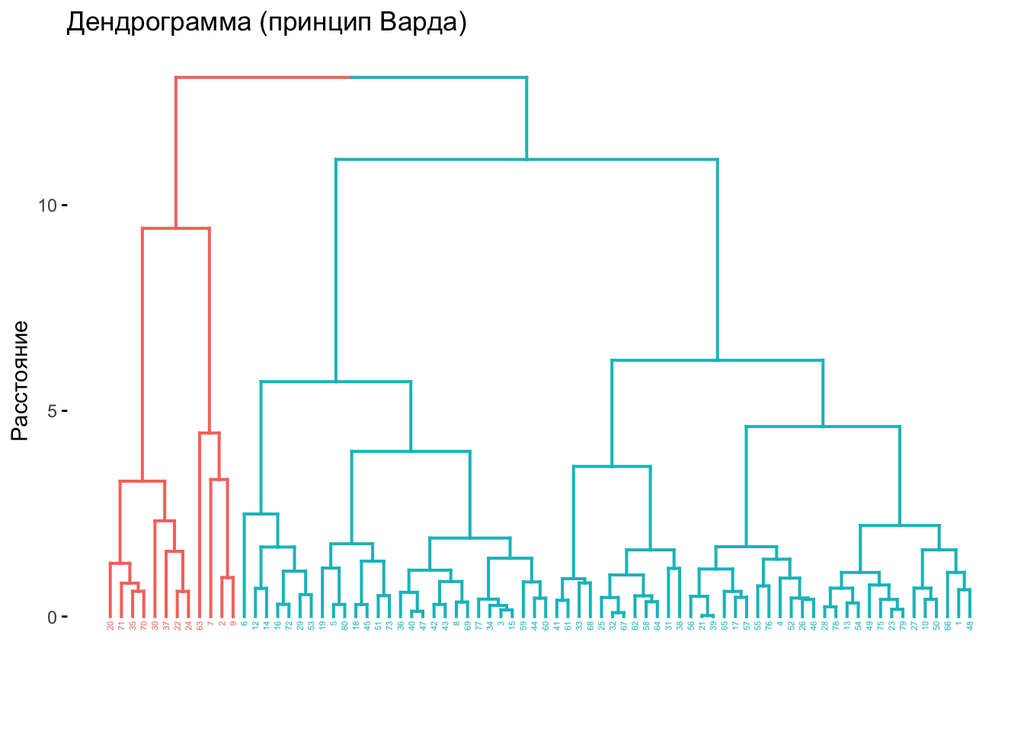

```r
fviz_dend(hclust, cex = 0.3, color_labels_by_k = TRUE, main = 'Дендрограмма (принцип Варда)', ylab = 'Расстояние')
```

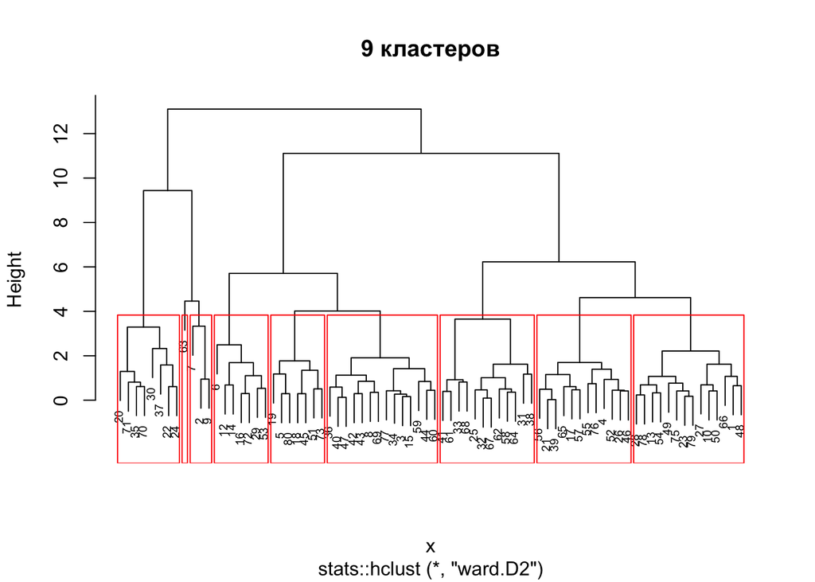

```r
plot(hclust, cex = 0.6, main = "9 кластеров")
rect.hclust(hclust, k = 9, border="red")
```

По дендограмме можно сделать вывод, что 9 — оптимальное число кластеров.

4. Приступлю к методу k-средних. Воспользуюсь elbow method для выбора числа кластеров (аналогично, для начала необходимо удалить некоторые столбцы).

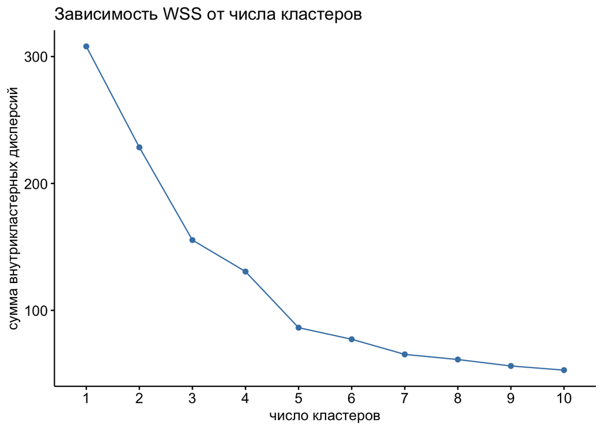

```r
fviz_nbclust(cluster_data, kmeans, method = 'wss') +
  labs(x = 'число кластеров', y = 'сумма внутрикластерных дисперсий',
       title = 'Зависимость WSS от числа кластеров')
```

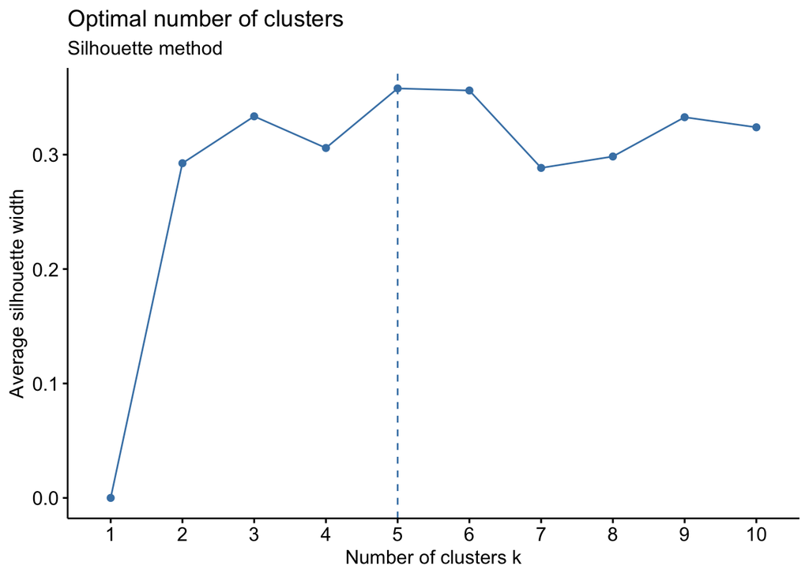

```r
fviz_nbclust(cluster_data, kmeans, method = "silhouette") +
  labs(subtitle = "Silhouette method")
```

Получается, оптимальное число кластеров = 5. С помощью дендограммы же получилосьчисло 9. Осуществлю кластеризацию для двух этих значений $k$ и визуализирую результат (метрика снова евклидова, выбор уже был обоснован раннее):

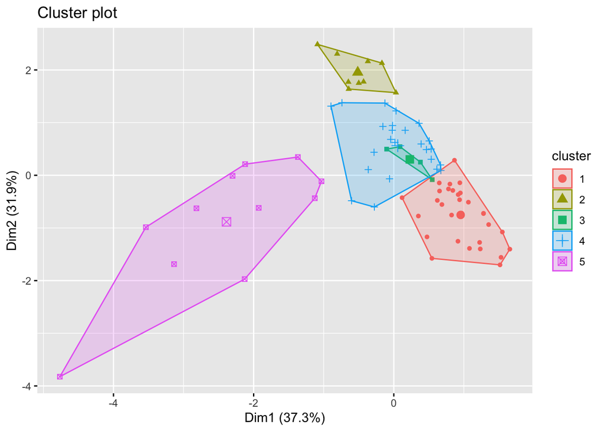

```r
kmeans1 <- kmeans(cluster_data, centers = 5)
kmeans2 <- kmeans(cluster_data, centers = 9)
fviz_cluster(kmeans1, cluster_data, frame = FALSE, geom = "point")
```

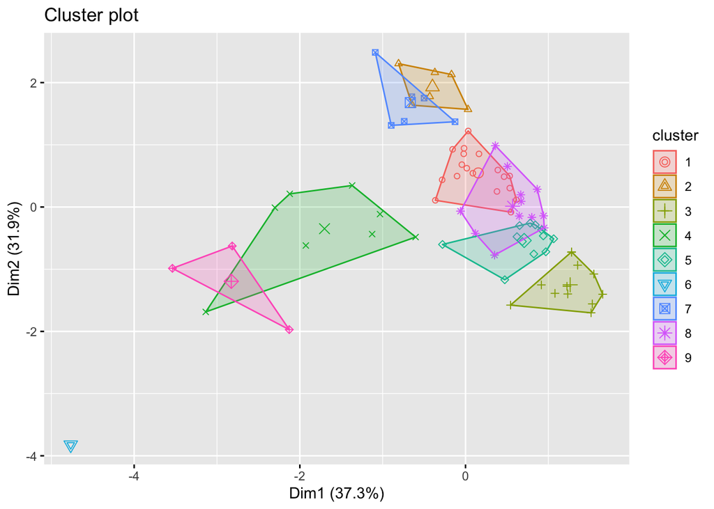

```r
fviz_cluster(kmeans2, cluster_data, frame = FALSE, geom = "point")
```

Как видно, на первом графике (при $k$ = 5) данные распределены более равномерно. Поэтому наиболее подходящий вариант равен 5.

Как видно по графику, фиолетовый кластер находится левее значения -1 по оси х, все остальные находятся правее и различаются относительно оси у.

Вывод: я выяснил, что между переменными publications_count и population, GDP и primary_ed_idx, GDP и avg_salary, primary_ed_idx и avg_salary существует высокая прямая корреляция, и что оптимальное число кластеров = 5.